# EAE127_P1_AUNG_EPHRAIM

Setup

```python
#STANDARD IMPORTS
import sympy as sp
import numpy as np
import os
import matplotlib.pyplot as plt
### JUPYTER NOTEBOOK SETTINGS ########################################
#Plot all figures in full-size cells, no scroll bars
%matplotlib inline
#Disable Python Warning Output
#(NOTE: Only for production, comment out for debugging)
import warnings
warnings.filterwarnings('ignore')
### PLOTTING DEFAULTS BOILERPLATE (OPTIONAL) #########################
#SET DEFAULT FIGURE APPERANCE
import seaborn as sns #Fancy plotting package
#No Background fill, legend font scale, frame on legend
sns.set(style='whitegrid', font_scale=1.5, rc={'legend.frameon': True})
#Mark ticks with border on all four sides (overrides 'whitegrid')
sns.set_style('ticks')
#ticks point in
sns.set_style({"xtick.direction": "in","ytick.direction": "in"})
#fix invisible marker bug
sns.set_context(rc={'lines.markeredgewidth': 0.1})
#restore default matplotlib colormap
mplcolors = ['#1f77b4', '#ff7f0e', '#2ca02c', '#d62728', '#9467bd',
'#8c564b', '#e377c2', '#7f7f7f', '#bcbd22', '#17becf']
sns.set_palette(mplcolors)

#Get color cycle for manual colors
colors = sns.color_palette()
#SET MATPLOTLIB DEFAULTS
#(call after seaborn, which changes some defaults)
params = {
#FONT SIZES
'axes.labelsize' : 30, #Axis Labels
'axes.titlesize' : 30, #Title
'font.size' : 28, #Textbox
'xtick.labelsize': 22, #Axis tick labels
'ytick.labelsize': 22, #Axis tick labels
'legend.fontsize': 24, #Legend font size
'font.family' : 'serif',
'font.fantasy' : 'xkcd',
'font.sans-serif': 'Helvetica',
'font.monospace' : 'Courier',
#AXIS PROPERTIES
'axes.titlepad' : 2*6.0, #title spacing from axis
'axes.grid' : True, #grid on plot
'figure.figsize' : (8,8), #square plots
'savefig.bbox' : 'tight', #reduce whitespace in saved figures
#LEGEND PROPERTIES
'legend.framealpha' : 0.5,
'legend.fancybox' : True,
'legend.frameon' : True,
'legend.numpoints' : 1,
'legend.scatterpoints' : 1,
'legend.borderpad' : 0.1,
'legend.borderaxespad' : 0.1,
'legend.handletextpad' : 0.2,
'legend.handlelength' : 1.0,
'legend.labelspacing' : 0,
}
import matplotlib
matplotlib.rcParams.update(params) #update matplotlib defaults, call after
### END OF BOILERPLATE ##################################################
colors = sns.color_palette() #color cycle
```

For each of the plots: Chord length (c=1), Camber line must be plotted as a dotted line, Label upper and lower surface seperately , Chord Line, Use equal axes when plotting

Notes

1.1 Designing Symmetric Airfoils

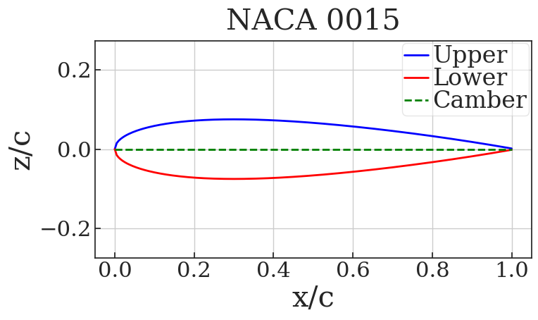

```python
#NACA Code Input
n1=0
n2=0
n3=1
n4=5

#define variables
c=1 #chord length
maxcam=(n1/100)*c #max camber
maxcamp=(n2/10)*c #max camber position
maxt= (((n3*10)+n4)/100)*c #max thickness
t=maxt/c #thickness


x=np.linspace(0,1,201)

zt=c*(t/0.2)*(
    (0.2969*np.sqrt(x/c))
    -(0.1260*(x/c))
    -(0.3516*(x/c)**2)
    +(0.2843*(x/c)**3)
    -(0.1015*(x/c)**4)
    )


UpperSurface= zt
LowerSurface=-zt

AreaUpper = np.trapz(UpperSurface, x)  # Area under upper surface
AreaLower = np.trapz(LowerSurface, x)  # Area under lower surface

# The chord line is the average of the areas
ChordLine = (AreaUpper - AreaLower) / c
CamberLine = (UpperSurface + LowerSurface) / 2


naca_code = f"NACA {n1}{n2}{n3}{n4}"

# Plotting
plt.figure(figsize=(8, 4))
plt.title(f'{naca_code}')  # Auto-populated title
plt.xlabel("x/c")
plt.ylabel("z/c")
plt.plot(x, UpperSurface, label="Upper", color='blue', linestyle="-", linewidth=2, markersize=8)
plt.plot(x, LowerSurface, label="Lower", color='red', linestyle="-", linewidth=2, markersize=8)
plt.plot(x, CamberLine, label='Camber', color='green', linestyle='--', linewidth=2)
plt.grid(True)
plt.axis('equal')
plt.legend()


#print("Surface Coordinates (x, UpperSurface, LowerSurface):")
#for i in range(len(x)):
#    print(f"x = {x[i]:.4f}, UpperSurface = {UpperSurface[i]:.4f}, LowerSurface = {LowerSurface[i]:.4f}")
```

1.2 Designing Cambered Airfoils Airfoil 1

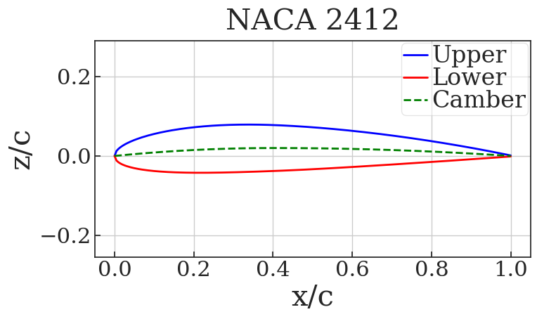

```python
#NACA Code Input
n1=2 #must be nonzero
n2=4 #must be nonzero
n3=1
n4=2

#define variables
c=1 #chord length
maxcam=(n1/100)*c #max camber
maxcamp=(n2/10)*c #max camber position
maxt= (((n3*10)+n4)/100)*c #max thickness
t=maxt/c #thickness
x=np.linspace(0,1,201)

p=maxcamp
m=maxcam

CamberLine = np.zeros_like(x)

# Calculate the CamberLine
for i in range(len(x)):
    if x[i] <= p:  # assumine c=1 (im not sure why it doesnt work when i multiply it by c)
        CamberLine[i] = (m / p**2) * (2 * p * (x[i]) - (x[i])**2)
    else:
        CamberLine[i] = (m / (1 - p)**2) * ((1 - 2 * p) + 2 * p * (x[i]) - (x[i])**2)

zt=c*(t/0.2)*(
    (0.2969*np.sqrt(x/c))
    -(0.1260*(x/c))
    -(0.3516*(x/c)**2)
    +(0.2843*(x/c)**3)
    -(0.1015*(x/c)**4)
    )


UpperSurface= zt + CamberLine
LowerSurface=-zt + CamberLine

naca_code = f"NACA {n1}{n2}{n3}{n4}"

# Plotting
plt.figure(figsize=(8, 4))
plt.title(f'{naca_code}')  # Auto-populated title
plt.xlabel("x/c")
plt.ylabel("z/c")
plt.plot(x, UpperSurface, label="Upper", color='blue', linestyle="-", linewidth=2, markersize=8)
plt.plot(x, LowerSurface, label="Lower", color='red', linestyle="-", linewidth=2, markersize=8)
plt.plot(x, CamberLine, label='Camber', color='green', linestyle='--', linewidth=2)
plt.grid(True)
plt.axis('equal')
plt.legend()


#print("Surface Coordinates (x, UpperSurface, LowerSurface):")
#for i in range(len(x)):
#    print(f"x = {x[i]:.4f}, UpperSurface = {UpperSurface[i]:.4f}, LowerSurface = {LowerSurface[i]:.4f}")
```

1.2 Designing Cambered Airfoils Airfoil 2

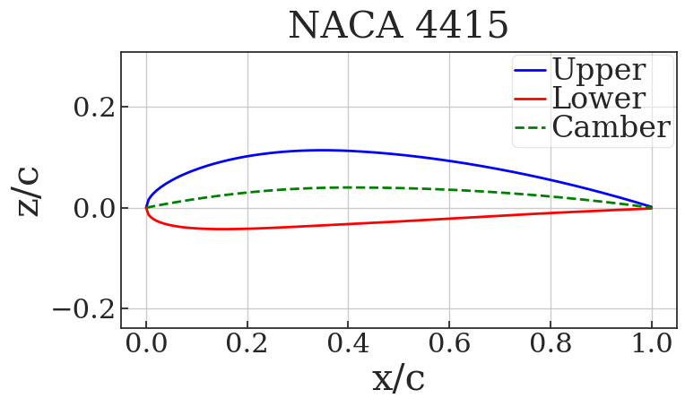

```python
#NACA Code Input
n1=4 #must be nonzero
n2=4 #must be nonzero
n3=1
n4=5

#define variables
c=1 #chord length
maxcam=(n1/100)*c #max camber
maxcamp=(n2/10)*c #max camber position
maxt= (((n3*10)+n4)/100)*c #max thickness
t=maxt/c #thickness
x=np.linspace(0,1,201)

p=maxcamp
m=maxcam

CamberLine = np.zeros_like(x)

# Calculate the CamberLine
for i in range(len(x)):
    if x[i] <= p:  # assumine c=1 (im not sure why it doesnt work when i multiply it by c)
        CamberLine[i] = (m / p**2) * (2 * p * (x[i]) - (x[i])**2)
    else:
        CamberLine[i] = (m / (1 - p)**2) * ((1 - 2 * p) + 2 * p * (x[i]) - (x[i])**2)

zt=c*(t/0.2)*(
    (0.2969*np.sqrt(x/c))
    -(0.1260*(x/c))
    -(0.3516*(x/c)**2)
    +(0.2843*(x/c)**3)
    -(0.1015*(x/c)**4)
    )


UpperSurface= zt + CamberLine
LowerSurface=-zt + CamberLine

naca_code = f"NACA {n1}{n2}{n3}{n4}"

# Plotting
plt.figure(figsize=(8, 4))
plt.title(f'{naca_code}')  # Auto-populated title
plt.xlabel("x/c")
plt.ylabel("z/c")
plt.plot(x, UpperSurface, label="Upper", color='blue', linestyle="-", linewidth=2, markersize=8)
plt.plot(x, LowerSurface, label="Lower", color='red', linestyle="-", linewidth=2, markersize=8)
plt.plot(x, CamberLine, label='Camber', color='green', linestyle='--', linewidth=2)
plt.grid(True)
plt.axis('equal')
plt.legend()

#print("Surface Coordinates (x, UpperSurface, LowerSurface):")
#for i in range(len(x)):
#    print(f"x = {x[i]:.4f}, UpperSurface = {UpperSurface[i]:.4f}, LowerSurface = {LowerSurface[i]:.4f}")
```

1.3 Designing NACA 5 Digit Airfoil

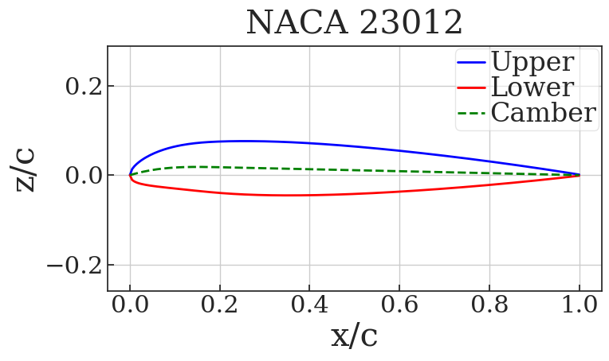

```python
#NACA Code Input
n1=2 #L
n2=3 #P  (typically 1-5)
n3=0 #S  (0 = simple 1= reflex (in this case always 0))
n4=1 #T
n5=2#T
# r and k1 value storage
rvalues = {1: 0.058, 2: 0.126, 3: 0.2025, 4: 0.29, 5: 0.391}
k1values = {1: 361.4, 2: 51.64, 3: 15.957, 4: 6.643, 5: 3.23}
#selects values based on corresponding n2 number
r=rvalues[n2]
k1=k1values[n2]

c=1 #Chord Length
Cl=n1 #Coefficient of lift
#MaxCamP=n2*0.05 #not used because n2 is used for the r and k1 values
MaxT=(((n4*10)+n5)/100)*c #Maximum Thickness

x=np.linspace(0,c,201)

CamberLine = np.zeros_like(x)

for i in range(len(x)):
    if x[i] <= r:
        CamberLine[i] = (k1 / 6) * (x[i]**3 - 3 * r * x[i]**2 + r**2 * (3 - r) * x[i])
    else:
        CamberLine[i] = (k1 * r**3 / 6) * (1 - x[i])


CamberLineActual=CamberLine*(Cl/2)

zt=c*(MaxT/0.2)*(
    (0.2969*np.sqrt(x/c))
    -(0.1260*(x/c))
    -(0.3516*(x/c)**2)
    +(0.2843*(x/c)**3)
    -(0.1015*(x/c)**4)
    )

UpperSurface= zt + CamberLine
LowerSurface=-zt + CamberLine


naca_code = f"NACA {n1}{n2}{n3}{n4}{n5}"

# Plotting
plt.figure(figsize=(8, 4))
plt.title(f'{naca_code}')  # Auto-populated title
plt.xlabel("x/c")
plt.ylabel("z/c")
plt.plot(x, UpperSurface, label="Upper", color='blue', linestyle="-", linewidth=2, markersize=8)
plt.plot(x, LowerSurface, label="Lower", color='red', linestyle="-", linewidth=2, markersize=8)
plt.plot(x, CamberLineActual, label='Camber', color='green', linestyle='--', linewidth=2)
plt.grid(True)
plt.axis('equal')
plt.legend()


#print("Surface Coordinates (x, UpperSurface, LowerSurface):")
#for i in range(len(x)):
#    print(f"x = {x[i]:.4f}, UpperSurface = {UpperSurface[i]:.4f}, LowerSurface = {LowerSurface[i]:.4f}")
```

2.0 XFOIL Introduction

```python
import pandas as pd
import sys
import pyxfoil

foil = '0012' #NACA airfoil number
naca = True   #allows NACA number input rather than geometry text file
Re   = 0      #Reynolds Number (iAIRFOIL (GEMOETRY FROM EQUATION, NOT FILE)
alfs = [0,4,12]#Angles of Attack to simulated
print("Running XFOIL/pyxfoil and saving data in 'Data/naca0012' folder...\n")
pyxfoil.GetPolar(foil, naca, alfs, Re, SaveCP=True, quiet=True)

filename=f"C:\\Users\\ephra\\OneDrive\\Desktop\\PythonScripts\\EAE127\\.git\\Data\\naca0012\\naca0012_polar_Re0.00e+00a0.0-12.0.dat"
alpha,CL,CD,CDp,CM,Top_Xtr,Bot_Xtr = np.loadtxt(filename, skiprows = 12, unpack = True)
print(alpha,CL,CD,CM)
```

```
Running XFOIL/pyxfoil and saving data in 'Data/naca0012' folder...

[ 0.  4. 12.] [0.     0.483  1.4395] [0. 0. 0.] [-0.     -0.0056 -0.0164]
```

```python
import pandas as pd
import sys
import pyxfoil

foil = '0012' #NACA airfoil number
naca = True   #allows NACA number input rather than geometry text file
Re   = 436034.9854     #Reynolds Number (iAIRFOIL (GEMOETRY FROM EQUATION, NOT FILE)
alfs = [0,4,12]#Angles of Attack to simulated
print("Running XFOIL/pyxfoil and saving data in 'Data/naca0012' folder...\n")
pyxfoil.GetPolar(foil, naca, alfs, Re, SaveCP=True, quiet=True)

filename=f"C:\\Users\\ephra\\OneDrive\\Desktop\\PythonScripts\\EAE127\\.git\\Data\\naca0012\\naca0012_polar_Re4.36e+05a0.0-12.0.dat"
alpha,CL,CD,CDp,CM,Top_Xtr,Bot_Xtr = np.loadtxt(filename, skiprows = 12, unpack = True)
print(alpha,CL,CD,CM)
```

```
Running XFOIL/pyxfoil and saving data in 'Data/naca0012' folder...

[ 0.  4. 12.] [0.     0.4973 1.1598] [0.00646 0.00943 0.02794] [-0.     -0.0073  0.0242]
```

```python
import pandas as pd
import sys
import pyxfoil

foil = '0012' #NACA airfoil number
naca = True   #allows NACA number input rather than geometry text file
Re   = 1490345.149     #Reynolds Number (iAIRFOIL (GEMOETRY FROM EQUATION, NOT FILE)
alfs = [0,4,12]#Angles of Attack to simulated
print("Running XFOIL/pyxfoil and saving data in 'Data/naca0012' folder...\n")
pyxfoil.GetPolar(foil, naca, alfs, Re, SaveCP=True, quiet=True)

filename=f"C:\\Users\\ephra\\OneDrive\\Desktop\\PythonScripts\\EAE127\\.git\\Data\\naca0012\\naca0012_polar_Re1.49e+06a0.0-12.0.dat"
alpha,CL,CD,CDp,CM,Top_Xtr,Bot_Xtr = np.loadtxt(filename, skiprows = 12, unpack = True)
print(alpha,CL,CD,CM)
```

```
Running XFOIL/pyxfoil and saving data in 'Data/naca0012' folder...

[ 0.  4. 12.] [0.     0.4315 1.2703] [0.00524 0.00673 0.01695] [-0.      0.0045  0.0099]
```

```python
import pandas as pd
import sys
import pyxfoil

foil = '23012' #NACA airfoil number
naca = True   #allows NACA number input rather than geometry text file
Re   = 0      #Reynolds Number (iAIRFOIL (GEMOETRY FROM EQUATION, NOT FILE)
alfs = [0,4,12]#Angles of Attack to simulated
print("Running XFOIL/pyxfoil and saving data in 'Data/naca0012' folder...\n")
pyxfoil.GetPolar(foil, naca, alfs, Re, SaveCP=True, quiet=True)

filename=f"C:\\Users\\ephra\\OneDrive\\Desktop\\PythonScripts\\EAE127\\.git\\Data\\naca23012\\naca23012_polar_Re0.00e+00a0.0-12.0.dat"
alpha,CL,CD,CDp,CM,Top_Xtr,Bot_Xtr = np.loadtxt(filename, skiprows = 12, unpack = True)
print(alpha,CL,CD,CM)
```

```
Running XFOIL/pyxfoil and saving data in 'Data/naca0012' folder...

[ 0.  4. 12.] [0.1376 0.6204 1.5747] [0. 0. 0.] [-0.0116 -0.0175 -0.0311]
```

```python
import pandas as pd
import sys
import pyxfoil

foil = '23012' #NACA airfoil number
naca = True   #allows NACA number input rather than geometry text file
Re   = 436034.9854       #Reynolds Number (iAIRFOIL (GEMOETRY FROM EQUATION, NOT FILE)
alfs = [0,4,12]#Angles of Attack to simulated
print("Running XFOIL/pyxfoil and saving data in 'Data/naca0012' folder...\n")
pyxfoil.GetPolar(foil, naca, alfs, Re, SaveCP=True, quiet=True)

filename=f"C:\\Users\\ephra\\OneDrive\\Desktop\\PythonScripts\\EAE127\\.git\\Data\\naca23012\\naca23012_polar_Re4.36e+05a0.0-12.0.dat"
alpha,CL,CD,CDp,CM,Top_Xtr,Bot_Xtr = np.loadtxt(filename, skiprows = 12, unpack = True)
print(alpha,CL,CD,CM)
```

```
Running XFOIL/pyxfoil and saving data in 'Data/naca0012' folder...

[ 0.  4. 12.] [0.1143 0.6432 1.3686] [0.00705 0.0106  0.01945] [-0.0057 -0.0231  0.0022]
```

```python
import pandas as pd
import sys
import pyxfoil

foil = '23012' #NACA airfoil number
naca = True   #allows NACA number input rather than geometry text file
Re   = 1490345.149      #Reynolds Number (iAIRFOIL (GEMOETRY FROM EQUATION, NOT FILE)
alfs = [0,4,12]#Angles of Attack to simulated
print("Running XFOIL/pyxfoil and saving data in 'Data/naca0012' folder...\n")
pyxfoil.GetPolar(foil, naca, alfs, Re, SaveCP=True, quiet=True)

filename=f"C:\\Users\\ephra\\OneDrive\\Desktop\\PythonScripts\\EAE127\\.git\\Data\\naca23012\\naca23012_polar_Re1.49e+06a0.0-12.0.dat"
alpha,CL,CD,CDp,CM,Top_Xtr,Bot_Xtr = np.loadtxt(filename, skiprows = 12, unpack = True)
print(alpha,CL,CD,CM)
```

```
Running XFOIL/pyxfoil and saving data in 'Data/naca0012' folder...

[ 0.  4. 12.] [0.1253 0.5623 1.4203] [0.00612 0.0072  0.01436] [-0.0096 -0.006  -0.0059]
```

```python
import pandas as pd
import sys
import pyxfoil

foil = '2612' #NACA airfoil number
naca = True   #allows NACA number input rather than geometry text file
Re   = 0      #Reynolds Number (iAIRFOIL (GEMOETRY FROM EQUATION, NOT FILE)
alfs = [0,4,12]#Angles of Attack to simulated
print("Running XFOIL/pyxfoil and saving data in 'Data/naca0012' folder...\n")
pyxfoil.GetPolar(foil, naca, alfs, Re, SaveCP=True, quiet=True)

filename=f"C:\\Users\\ephra\\OneDrive\\Desktop\\PythonScripts\\EAE127\\.git\\Data\\naca2612\\naca2612_polar_Re0.00e+00a0.0-12.0.dat"
alpha,CL,CD,CDp,CM,Top_Xtr,Bot_Xtr = np.loadtxt(filename, skiprows = 12, unpack = True)
print(alpha,CL,CD,CM)
```

```
Running XFOIL/pyxfoil and saving data in 'Data/naca0012' folder...

[ 0.  4. 12.] [0.3149 0.7969 1.7469] [0. 0. 0.] [-0.0787 -0.0845 -0.0954]
```

```python
import pandas as pd
import sys
import pyxfoil

foil = '2612' #NACA airfoil number
naca = True   #allows NACA number input rather than geometry text file
Re   = 436034.9854     #Reynolds Number (iAIRFOIL (GEMOETRY FROM EQUATION, NOT FILE)
alfs = [0,4,12]#Angles of Attack to simulated
print("Running XFOIL/pyxfoil and saving data in 'Data/naca0012' folder...\n")
pyxfoil.GetPolar(foil, naca, alfs, Re, SaveCP=True, quiet=True)

filename=f"C:\\Users\\ephra\\OneDrive\\Desktop\\PythonScripts\\EAE127\\.git\\Data\\naca2612\\naca2612_polar_Re4.36e+05a0.0-12.0.dat"
alpha,CL,CD,CDp,CM,Top_Xtr,Bot_Xtr = np.loadtxt(filename, skiprows = 12, unpack = True)
print(alpha,CL,CD,CM)
```

```
Running XFOIL/pyxfoil and saving data in 'Data/naca0012' folder...

[ 0.  4. 12.] [0.2957 0.7238 1.326 ] [0.00719 0.00853 0.02872] [-0.0759 -0.0685 -0.0258]
```

```python
import pandas as pd
import sys
import pyxfoil

foil = '2612' #NACA airfoil number
naca = True   #allows NACA number input rather than geometry text file
Re   = 1490345.149      #Reynolds Number (iAIRFOIL (GEMOETRY FROM EQUATION, NOT FILE)
alfs = [0,4,12]#Angles of Attack to simulated
print("Running XFOIL/pyxfoil and saving data in 'Data/naca0012' folder...\n")
pyxfoil.GetPolar(foil, naca, alfs, Re, SaveCP=True, quiet=True)

filename=f"C:\\Users\\ephra\\OneDrive\\Desktop\\PythonScripts\\EAE127\\.git\\Data\\naca2612\\naca2612_polar_Re1.49e+06a0.0-12.0.dat"
alpha,CL,CD,CDp,CM,Top_Xtr,Bot_Xtr = np.loadtxt(filename, skiprows = 12, unpack = True)
print(alpha,CL,CD,CM)
```

```
Running XFOIL/pyxfoil and saving data in 'Data/naca0012' folder...

[ 0.  4. 12.] [0.2989 0.7279 1.4681] [0.00506 0.00698 0.01838] [-0.075  -0.0706 -0.0456]
```

2.1 Symmetric vs Cambered Airfoil Surface Pressure Comparison

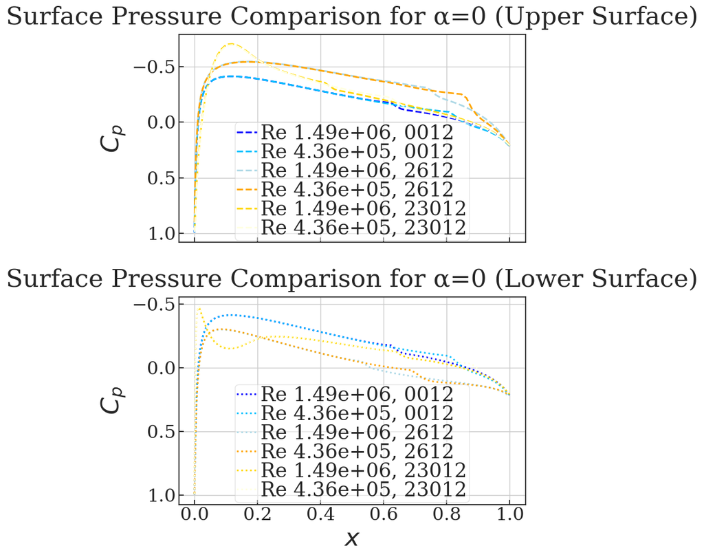

```python
# Surface Pressure Comparison
# For Alpha = 0
# Import Data


base_path1 = 'C:\\Users\\ephra\\OneDrive\\Desktop\\PythonScripts\\EAE127\\.git\\Data\\naca0012'
base_path2 = 'C:\\Users\\ephra\\OneDrive\\Desktop\\PythonScripts\\EAE127\\.git\\Data\\naca2612'
base_path3 = 'C:\\Users\\ephra\\OneDrive\\Desktop\\PythonScripts\\EAE127\\.git\\Data\\naca23012'

def load_cp_data(filename):
    return np.loadtxt(filename, skiprows=3, unpack=True, delimiter=None, usecols=(0, 2))

# Airfoil NACA 0012
x1, Cp1 = load_cp_data(os.path.join(base_path1, 'naca0012_surfCP_Re1.49e+06a0.0.dat'))
x1u, x1l = x1[:(len(x1)//2)], x1[(len(x1)//2):]
Cp1u, Cp1l = Cp1[:(len(Cp1)//2)], Cp1[(len(Cp1)//2):]

x2, Cp2 = load_cp_data(os.path.join(base_path1, 'naca0012_surfCP_Re4.36e+05a0.0.dat'))
x2u, x2l = x2[:(len(x2)//2)], x2[(len(x2)//2):]
Cp2u, Cp2l = Cp2[:(len(Cp2)//2)], Cp2[(len(Cp2)//2):]

# Airfoil NACA 2612
x3, Cp3 = load_cp_data(os.path.join(base_path2, 'naca2612_surfCP_Re1.49e+06a0.0.dat'))
x3u, x3l = x3[:(len(x3)//2)], x3[(len(x3)//2):]
Cp3u, Cp3l = Cp3[:(len(Cp3)//2)], Cp3[(len(Cp3)//2):]

x4, Cp4 = load_cp_data(os.path.join(base_path2, 'naca2612_surfCP_Re4.36e+05a0.0.dat'))
x4u, x4l = x4[:(len(x4)//2)], x4[(len(x4)//2):]
Cp4u, Cp4l = Cp4[:(len(Cp4)//2)], Cp4[(len(Cp4)//2):]

# Airfoil NACA 23012
x5, Cp5 = load_cp_data(os.path.join(base_path3, 'naca23012_surfCP_Re1.49e+06a0.0.dat'))
x5u, x5l = x5[:(len(x5)//2)], x5[(len(x5)//2):]
Cp5u, Cp5l = Cp5[:(len(Cp5)//2)], Cp5[(len(Cp5)//2):]

x6, Cp6 = load_cp_data(os.path.join(base_path3, 'naca23012_surfCP_Re4.36e+05a0.0.dat'))
x6u, x6l = x6[:(len(x6)//2)], x6[(len(x6)//2):]
Cp6u, Cp6l = Cp6[:(len(Cp6)//2)], Cp6[(len(Cp6)//2):]

# Create Subplots
fig, (ax1, ax2) = plt.subplots(2, 1, figsize=(8, 10), sharex=True)

# Upper Surface Plot
ax1.set_title('Surface Pressure Comparison for α=0 (Upper Surface)')
ax1.set_ylabel("$C_p$")

ax1.plot(x1u, Cp1u, label='Re 1.49e+06, 0012', linewidth=2, linestyle='--', color='blue')
ax1.plot(x2u, Cp2u, label='Re 4.36e+05, 0012', linewidth=2, linestyle='--', color='deepskyblue')
ax1.plot(x3u, Cp3u, label='Re 1.49e+06, 2612', linewidth=2, linestyle='--', color='lightblue')
ax1.plot(x4u, Cp4u, label='Re 4.36e+05, 2612', linewidth=2, linestyle='--', color='orange')
ax1.plot(x5u, Cp5u, label='Re 1.49e+06, 23012', linewidth=2, linestyle='--', color='gold')
ax1.plot(x6u, Cp6u, label='Re 4.36e+05, 23012', linewidth=2, linestyle='--', color='lightyellow')

ax1.invert_yaxis()  # Invert y-axis for Cp
ax1.grid(True)
ax1.legend(loc='best')

# Lower Surface Plot
ax2.set_title('Surface Pressure Comparison for α=0 (Lower Surface)')
ax2.set_xlabel("$x$")
ax2.set_ylabel("$C_p$")

ax2.plot(x1l, Cp1l, label='Re 1.49e+06, 0012', linewidth=2, linestyle='dotted', color='blue')
ax2.plot(x2l, Cp2l, label='Re 4.36e+05, 0012', linewidth=2, linestyle='dotted', color='deepskyblue')
ax2.plot(x3l, Cp3l, label='Re 1.49e+06, 2612', linewidth=2, linestyle='dotted', color='lightblue')
ax2.plot(x4l, Cp4l, label='Re 4.36e+05, 2612', linewidth=2, linestyle='dotted', color='orange')
ax2.plot(x5l, Cp5l, label='Re 1.49e+06, 23012', linewidth=2, linestyle='dotted', color='gold')
ax2.plot(x6l, Cp6l, label='Re 4.36e+05, 23012', linewidth=2, linestyle='dotted', color='lightyellow')

ax2.invert_yaxis()  # Invert y-axis for Cp
ax2.grid(True)
ax2.legend(loc='best')

# Display plots
plt.tight_layout()
plt.show()
```